# 14.Example 2

Modified

Mo 2026-09-21 21:41

## Given:

A paint baking oven consists of a long, triangular duct in which a heated surface is maintained at $1200\ \mathrm{K}$ and another surface is insulated. Painted panels, which are maintained at $500\ \mathrm{K}$, occupy the third surface. The triangle is of width $W = 1\ \mathrm{m}$ on a side, and the heated and insulated surfaces have an emissivity of $0.8$. The emissivity of the panels is $0.4$.

## Required:

During steady-state operation, at what rate must energy be supplied to the heated side per unit length of the duct to maintain its temperature at $1200\ \mathrm{K}$? What is the temperature of the insulated surface?

## Solution:

Start first by defining all of the given values.

$$T_1 = 1200\ \mathrm{K}$$
$$T_2 = 500\ \mathrm{K}$$
$$W = 1\ \mathrm{m}$$
$$\varepsilon_1 = 0.8$$
$$\varepsilon_R = 0.8$$
$$\varepsilon_2 = 0.4$$

Other known quantities that will be used are shown below.

$$\sigma = 5.67\times 10^{-8}\ \frac{\mathrm{W}}{\left(\mathrm{K}^{4} \cdot \mathrm{m}^{2}\right)}$$

A sketch of the system is shown below.

Figure 1: System Sketch

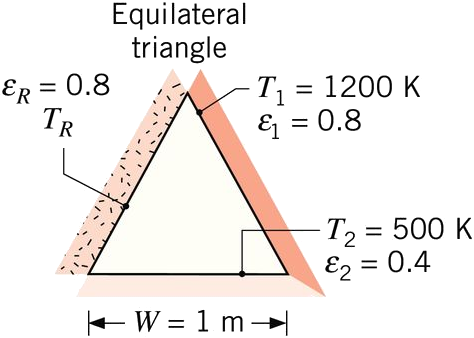

The equivalent radiation circuit is shown below.

Figure 2: Thermal Circuit

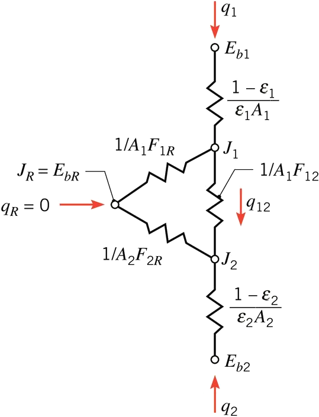

Referring to Table 15.1 for a three sided enclosure, the view factor is given by

$$F_{ij}=\frac{w_i+w_j-w_k}{2w_i}$$

For an equilateral triangle, all sides are equal thus the view factor becomes

$$F_{ij}=\frac{W+W-W}{2W} = \frac{1}{2}$$

or

$$F_{12} = 0.5$$
$$F_{1R} = 0.5$$
$$F_{2R} = 0.5$$

The equivalent resistance of the radiation circuit is

$$R_{tot}=\frac{1-\varepsilon_1}{\varepsilon_1 A_1}+\frac{1}{A_1 F_{12} + \frac{1}{\frac{1}{A_1 F_{1R}}+\frac{1}{A_2 F_{2R}}}}+\frac{1-\varepsilon_2}{\varepsilon_2 A_2}$$

All the area terms may be expressed at the product of the width $W$ and the length $L$. This is shown below.

$$R_{tot}=\frac{1-\varepsilon_1}{\varepsilon_1 W L}+\frac{1}{W L F_{12} + \frac{1}{\frac{1}{W L F_{1R}}+\frac{1}{W L F_{2R}}}}+\frac{1-\varepsilon_2}{\varepsilon_2 W L}$$

Inspecting the expression, it may be seen that there appears a length term $L$ in each denominator. The length terms $L$ may be factored out to produce

$$R_{tot} L=\frac{1-\varepsilon_1}{\varepsilon_1 W}+\frac{1}{W F_{12} + \frac{1}{\frac{1}{W F_{1R}}+\frac{1}{W F_{2R}}}}+\frac{1-\varepsilon_2}{\varepsilon_2 W}$$

$$R_{tot}L = \frac{1 - \varepsilon_1}{\varepsilon_1 W} + \frac{1}{W F_{12} + \frac{1}{\frac{1}{W F_{1R}} + \frac{1}{W F_{2R}}}} + \frac{1 - \varepsilon_2}{\varepsilon_2 W} = 3.083\ \frac{1}{\mathrm{m}}$$

The necessary heat rate to maintain the heat surface at the given temperature is given by

$$q_1=\frac{E_{b1} - E_{b2}}{R_{tot}}=\frac{\sigma \left( T_1^4 - T_2^4 \right)}{R_{tot}}$$

The heat rate per unit length is given by

Answer, part 1: $q_1^\prime = \frac{q_1}{L} = \frac{\sigma (T_1^4 - T_2^4)}{R_{tot} L} = 36.98\ \frac{\mathrm{kW}}{\mathrm{m}}$

From the circuit network, it may be seen that

$$q_2^\prime = -q_1^\prime = -36.98\ \frac{\mathrm{kW}}{\mathrm{m}}$$

To determine the temperature of the insulated surface, radiosity at the insulated surface $J_R$ must be determined. To determine $J_R$, the radiosities at surface 1 and 2 must be determined. From the circuit network it may be seen that the radiosity at surface 1 is given by

$$J_1 = E_{b1} - \frac{1 - \varepsilon_1}{\varepsilon_1 W} q_1^\prime = \sigma T_1^4 - \frac{1 - \varepsilon_1}{\varepsilon_1 W} q_1^\prime = 108.3\ \frac{\mathrm{kW}}{\mathrm{m}^{2}}$$

Similarly, the radiosity at surface 2 is given by

$$J_2 = E_{b2} - \frac{1 - \varepsilon_2}{\varepsilon_2 W} q_2^\prime = \sigma T_2^4 - \frac{1 - \varepsilon_2}{\varepsilon_2 W} q_2^\prime = 59.02\ \frac{\mathrm{kW}}{\mathrm{m}^{2}}$$

The heat rate between surface 1 and 2 is given by

$$q_{12}=\frac{J_1 - J_2}{\frac{1}{A_1 F_{12}}}$$

Expressing the area in terms of the width $W$ and length $L$ shows

$$q_{12}=\frac{J_1 - J_2}{\frac{1}{W L F_{12}}}$$

Factoring out the length term $L$ shows the heat rate per unit length between surface 1 and 2 is given by

$$q_{12}^\prime = \frac{q_{12}}{L} = \frac{J_1 - J_2}{\frac{1}{W F_{12}}} = 24.65\ \frac{\mathrm{kW}}{\mathrm{m}}$$

The heat rate per unit length between surface 1 and the insulated surface is then given by

$$q_{1R}^\prime = q_1^\prime-q_{12}^\prime = 12.33\ \frac{\mathrm{kW}}{\mathrm{m}}$$

The radiosity of the insulated surface is then

$$J_R = J_1 - \frac{1}{W F_{1R}}q_{1R}^\prime = 83.67\ \frac{\mathrm{kW}}{\mathrm{m}^{2}}$$

Since the surface is insulated, the radiosity and the emissivity are equal or

$$J_R=E_{bR}=\sigma T_R^4$$

Solving for the insulated surface temperature $T_R$ shows

Answer, part 2: $T_R = (\frac{J_R}{\sigma})^{\frac{1}{4}} = 1102.2\ \mathrm{K}$